# Lab 2: Data Understanding & Exploratory Data Analysis

### 5.2 Streudiagramm-Matrix: alle Variablen auf einmal

**Code anzeigen**

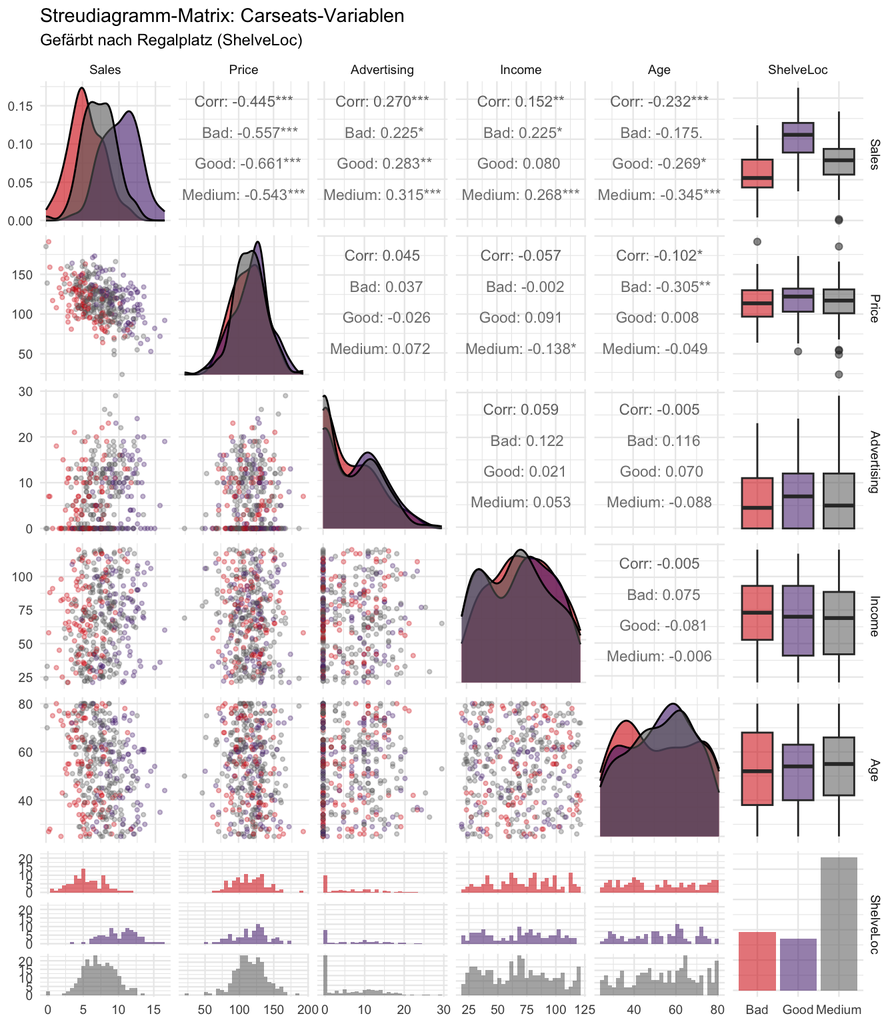

```r
tbl_carseats %>%
  select(Sales, Price, Advertising, Income, Age, ShelveLoc) %>%
  ggpairs(
    aes(color = ShelveLoc, alpha = 0.5),
    upper = list(continuous = wrap("cor", size = 3)),
    lower = list(continuous = wrap("points", alpha = 0.3, size = 0.8)),
    diag  = list(continuous = wrap("densityDiag", alpha = 0.6))
  ) +
  scale_color_manual(values = c(
    "Bad"    = "#D50006",
    "Medium" = "#686868",
    "Good"   = "#502479"
  )) +
  scale_fill_manual(values = c(
    "Bad"    = "#D50006",
    "Medium" = "#686868",
    "Good"   = "#502479"
  )) +
  theme_minimal(base_size = 9) +
  labs(title = "Streudiagramm-Matrix: Carseats-Variablen",
       subtitle = "Gefärbt nach Regalplatz (ShelveLoc)")
```

**NoteGGally::ggpairs() — EDA mit einer Zeile Code**

`ggpairs()` aus dem `GGally`-Paket erstellt in einer Zeile:

- **Diagonale:** Verteilungen der einzelnen Variablen
- **Oberes Dreieck:** Korrelationskoeffizienten
- **Unteres Dreieck:** Streudiagramme aller Variablenpaare

Das ist die effizienteste EDA-Technik für erste Mustersuche in tabellarischen Daten.

**Caution A3: Bivariate Analyse**

1. Welche Variablen korrelieren **am stärksten** mit `Sales`? Erstellen Sie eine geordnete Rangliste:

```r
tbl_carseats %>%
  select(where(is.numeric)) %>%
  cor() %>%
  as_tibble(rownames = "variable") %>%
  select(variable, Sales) %>%
  arrange(desc(abs(Sales)))
```

2. Gibt es Variablen die **untereinander** stark korrelieren (Multikollinearitätsverdacht)? Was könnte das für eine multiple Regression bedeuten?
3. Beschreiben Sie den Zusammenhang zwischen `ShelveLoc` und `Sales` in Worten. Welche Regalplatzkategorie hat den höchsten durchschnittlichen Umsatz?

```r
tbl_carseats %>%
  group_by(ShelveLoc) %>%
  summarise(mean_sales = mean(Sales),
            sd_sales   = sd(Sales),
            n          = n())
```

## 6 Schritt 4: Hypothesen formulieren

**Code anzeigen**

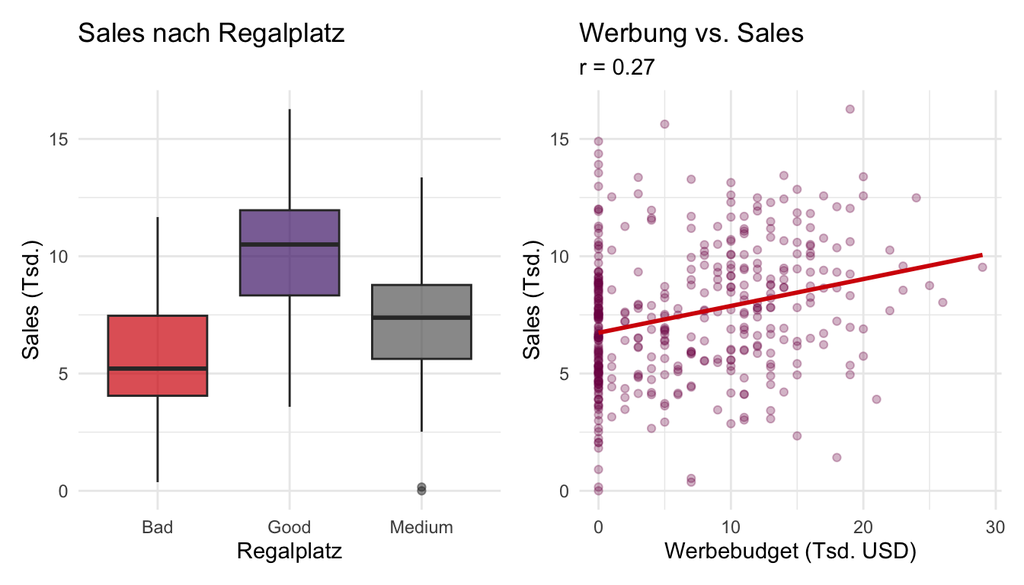

```r
# Boxplot: Sales nach ShelveLoc
p_shelf <- tbl_carseats %>%
  ggplot(aes(x = ShelveLoc, y = Sales, fill = ShelveLoc)) +
  geom_boxplot(alpha = 0.7, outlier.alpha = 0.5) +
  scale_fill_manual(values = c("Bad" = "#D50006",
                               "Medium" = "#686868",
                               "Good" = "#502479")) +
  labs(title = "Sales nach Regalplatz",
       x = "Regalplatz", y = "Sales (Tsd.)") +
  theme_minimal(base_size = 11) +
  theme(legend.position = "none")

# Streudiagramm: Advertising vs. Sales
p_adv <- tbl_carseats %>%
  ggplot(aes(x = Advertising, y = Sales)) +
  geom_point(alpha = 0.3, color = "#7d0a52", size = 1.5) +
  geom_smooth(method = "lm", color = "#D50006", se = FALSE) +
  labs(title = "Werbung vs. Sales",
       subtitle = paste0("r = ",
                         round(cor(tbl_carseats$Advertising,
                                   tbl_carseats$Sales), 3)),
       x = "Werbebudget (Tsd. USD)", y = "Sales (Tsd.)") +
  theme_minimal(base_size = 11)

p_shelf + p_adv
```

**Caution A4: Hypothesen für die Modellierung**

Auf Basis Ihrer EDA: Formulieren Sie **zwei Hypothesen** im Hinblick auf das Ziel „Identifikation von Underperformer-Filialen”.

**Beispielstruktur:** > *“Ich erwarte, dass [Variable X] einen [positiven/negativen] Zusammenhang mit Sales hat, > weil [inhaltliche Begründung].”*

## 7 Bonusaufgaben

**Tip B1: Preis-Elastizität schätzen**

Fitten Sie eine einfache log-log-Regression und interpretieren Sie den Koeffizienten als Preiselastizität des Umsatzes:

```r
library(moderndive)

# Log-Log-Modell: beide Variablen logarithmiert
mod_loglog <- tbl_carseats %>%
  mutate(log_sales = log(Sales),
         log_price = log(Price)) %>%
  lm(log_sales ~ log_price, data = .)

get_regression_table(mod_loglog)
```

**Fragen:** - Was bedeutet der Koeffizient für `log_price` als Elastizität? - Ist der Wert ökonomisch plausibel? - Vergleichen Sie $R^2$ mit dem linearen Modell `Sales ~ Price`. Was ändert sich?

**Tip B2: Ausreißeranalyse**

Identifizieren Sie die 5 Filialen mit dem höchsten und niedrigsten Umsatz. Was haben sie gemeinsam?

```r
tbl_carseats %>%
  mutate(rank = dense_rank(desc(Sales))) %>%
  filter(rank <= 5 | rank >= (n() - 4)) %>%
  select(Sales, Price, Advertising, ShelveLoc, Income, rank) %>%
  arrange(rank)
```

Gibt es Filialen mit **extremen Preis-Umsatz-Kombinationen** (hoher Preis aber trotzdem hoher Umsatz — oder umgekehrt)? Das könnte auf Ausreißer hindeuten, die eine gesonderte Modellierung erfordern.

**Tip B3: Segmentierte EDA**

Führen Sie die EDA **getrennt** für urbane und nicht-urbane Filialen durch. Unterscheiden sich die Preiseffekte?

```r
tbl_carseats %>%
  ggplot(aes(x = Price, y = Sales, color = Urban)) +
  geom_point(alpha = 0.4, size = 1.5) +
  geom_smooth(method = "lm", se = FALSE, linewidth = 1.2) +
  scale_color_manual(values = c("Yes" = "#502479", "No" = "#D50006")) +
  facet_wrap(~US) +
  labs(title = "Price vs. Sales nach Lage (Urban) und Region (US)",
       x = "Preis (USD)", y = "Sales (Tsd.)") +
  theme_minimal()
```

Was beobachten Sie? Gibt es Hinweise auf Interaktionseffekte?

## 8 Zusammenfassung

[output not shown]

**ImportantKernbotschaften dieses Labs**

Das motiviert das **multiple Regressionsmodell** in der Live-Demo.